# PM606Mingzhi_Ye

Mingzhi_Ye

6/25/2021

#Report01 ##pre-processing At first, we need to clear the useless and irrevalent predictors. What’s more, we should also eliminate the NA values. First, I remove all predictors whose NA values are more than 1/4. Those predictors are not lack too much values and are probably biased. There is an exception: date_of_death_dt. All the individuals who didn’t die until the end of the study shall be recorded as NA in “date_of_death_dt”. So I keep it and change all individuals’ “date_of_death_dt” to 4000-11-11 if and only is their “decease” is 0.

I also create several new variables. “month” record the month of “discharge_dt”. Then I also create “season” based on “month”. Then I also create “survive time to record how long do they survive after discharge. I also create”die30“,”die180, “die1800” to record whether they die in 30days 180days or 1800days. I also create “die_age” to record the age at which the individual die

```r
cdata<-read.csv("combined_data.csv")
#dim(cdata)

count_of_empty=c()
for(i in 1:154){
  count_of_empty[i]=0
}
for(i in 1:154){
  for(j in 1:132538){
    if(cdata[j,i]==''|is.na(cdata[j,i])){count_of_empty[i]=count_of_empty[i]+1}
  }
}

cdata2<-cdata[,count_of_empty/132538<1/4]
cdata2<-cbind(cdata2,cdata$date_of_death_dt)
cdata2<-cdata2 %>%
  rename(date_of_death_dt=`cdata$date_of_death_dt`)
cdata3<-cdata2
for(i in 1:132538){
  if(cdata3[i,99]==0)cdata3[i,100]="4000-11-11"
}
cdata4<-cdata3[complete.cases(cdata3),]

for(i in 1: 100){
  for(j in 1:35214 ){
    if(cdata4[j,i]==''){cdata4[j,i]=NA}
  }
}

cdata5<-cdata4[complete.cases(cdata4),]

write.csv(cdata5,"cdata5.csv",row.names = FALSE)
cdata5<-read.csv("cdata5.csv")

cdata5[c("participant_key","src_admission_cde","facility_county_cde","facility_zip5_cde",
       "qnr_1_fill_dt","qnr_2_fill_dt","qnr_3_fill_dt","qnr_4_fill_dt","allex_hrs_q1","nih_ethnic_cat",
       "stand_hrs","sit_hrs","vit_mulvit_q1","serv_fats_q1","alchl_g_dayrecen","smoke_lifeexpo",
       "passmok_expocat","smoke_totyrs","cig_day_avg","smoke_totpackyrs","shsmok_any","visit_id","admission_dt",
       "payer_plan_cde","age_mom_atbirth","age_dad_atbirth","breast_cancer_res_only_ind",
       "oralcntr_yrs","fullterm_age1st","preg_total_q1","meno_stattype","brca_selfsurvey","smoke_expocat","near_oilrefine")]<- list(NULL)
cdata5<-
  cdata5 %>%
  mutate(survivetime=as.numeric(as.Date(date_of_death_dt)-as.Date(discharge_dt)))

cdata5<-
  cdata5%>%
  mutate(die30= ifelse(survivetime<=30, 1, 0),
         die180= ifelse(survivetime<=180, 1, 0),
         die1800= ifelse(survivetime<=1800,1,0)
  )
cdata5<-
  cdata5%>%
  mutate(month=month(cdata5$discharge_dt))

cdata5<-
  cdata5%>%
  mutate(season= case_when(
    month<=3 ~ "spring",
    month<=6 ~ "summer",
    month<=9 ~ "autumn",
    month<=12 ~ "winter",

    TRUE~NA_character_
  ))

cdata5<-cdata5 %>%
  select(-month)

cdata5<-
 cdata5%>%
  mutate(die_age=as.numeric(year(date_of_death_dt)-year(date_of_birth_dt)))


cdata5$major_diag_cat_cde<-as.factor(cdata5$major_diag_cat_cde)
cdata5$participant_race<-as.factor(cdata5$participant_race)


write.csv(cdata5,"fudata.csv",row.names = FALSE)
fudata<-read.csv("fudata.csv")
fudata<-cdata5
fudata <- fudata %>%
  select(-date_of_death_dt,-date_of_birth_dt)
fudata<-
  fudata%>%
  mutate_at(c("mammo_ever_q1","major_diag_cat_cde","participant_race","ses_quartile_ind",
              "hysterectomy_ind","season","cholmed_daily","antidep_daily","sleep_hrs","allex_life_hrs",
              "bilateral_mastectomy_ind","bilateral_oophorectomy_ind","birthplace","participant_race",
              "menarche_age","oralcntr_ever_q1","preg_ever_q1","brca","blockgroup90_urban_cat",
              "hbpmed_totyrs","alchl_analyscat","smoke_statcat","asthma_q3",
              "insulin_daily","aceinhb_daily","othhbp_daily","tamox_daily","steroid_daily","brondil_daily"
              ), as.factor)
```

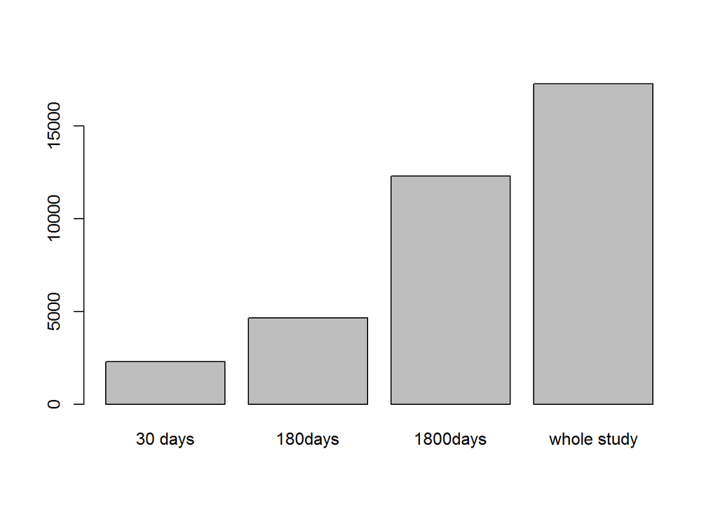

```r
#d30<-fudata %>%
#   select(-die180,-die1800, -survivetime, -discharge_dt,-die_age)
#
# y1=d30$die30
# x1=d30[,-69]
# d30_cvlasso<-cv.glmnet(x1,y1,family="binomial",alpha=1,type.measure = "mse")
# plot(d30_cvlasso)
# d30_lasso_coef=coef(d30_lasso)
dienumber=c(sum(fudata$die30),sum(fudata$die180),sum(fudata$die1800),sum(fudata$deceased))
timepoint=c("30 days","180days", "1800days","whole study")
barplot(dienumber,names.arg=timepoint)
```

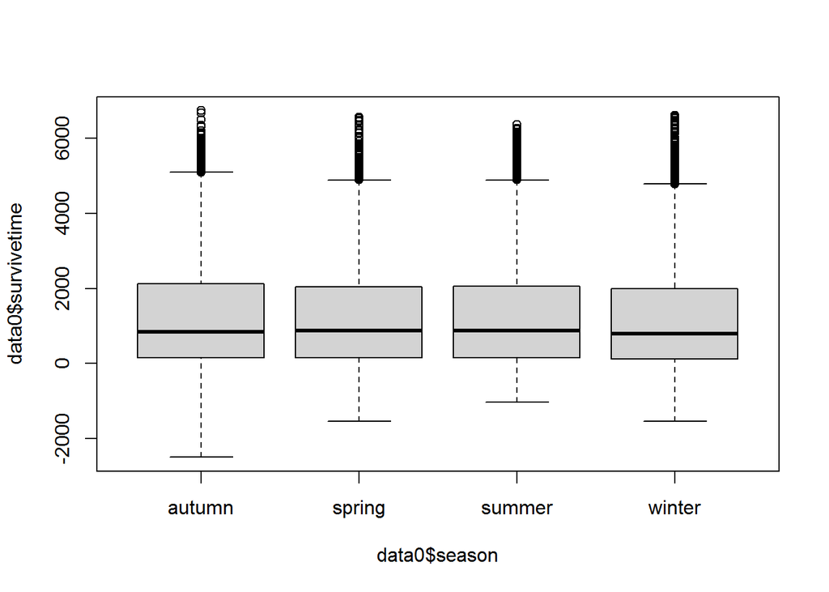

```r
data0<-fudata %>%
  filter(deceased==1)
boxplot(data0$survivetime~data0$season)
```